# Build-a-Booster Workshop

Alex Reinhart

10/28/2019

Let’s examine boosting. Boosting uses a series of “weak” classifiers – meaning simple ones with not-very-good accuracy – to build a better classifier.

Let’s suppose we have two variables, $X_1$ and $X_2$, and one outcome variable $Y$ that is either 0 or 1.

Our weak classifiers can be anything. Let’s use a *stump*: a classification tree with only one split. We’ll pick that split using the misclassification error, weighted by weights for each observation:

```r
misclass_error <- function(observed, predicted, weights) {
  sum(weights * ifelse(observed == predicted, 0, 1))
}
```

If we have $X$, $Y$, and some weights, and we want to pick the best split, how do we do it? Suppose $X$ is provided as a matrix with $N$ rows and 2 columns, and $Y$ is a vector with $N$ entries. This function picks the split that minimizes misclassification error, but you can ignore the details:

```r
## Ignore the details of this code! It just finds the split with the best misclassification error.
best_split <- function(X, Y, weights) {
  best_col <- 1
  best_split <- NA
  best_error <- Inf
  best_left_predict <- 0
  best_right_predict <- 0

  for (col in 1:ncol(X)) {
    for (val in unique(X[, col])) {
      left_idxs <- X[, col] < val

      if (sum(left_idxs) == 0 || sum(left_idxs) == nrow(X)) {
        ## This would put 0 data points on one side and all on the other;
        ## skip this option.
        next
      }

      left_ys <- Y[left_idxs]
      left_weights <- weights[left_idxs]
      right_ys <- Y[!left_idxs]
      right_weights <- weights[!left_idxs]

      left_predict <- if (sum(left_ys * left_weights) > 0.5 * sum(left_weights)) { 1 } else { 0 }
      right_predict <- if (sum(right_ys * right_weights) > 0.5 * sum(right_weights)) { 1 } else { 0 }

      this_error <- (misclass_error(left_ys, left_predict, left_weights) +
                       misclass_error(right_ys, right_predict, right_weights))

      if (this_error < best_error) {
        best_error <- this_error
        best_col <- col
        best_split <- val
        best_left_predict <- left_predict
        best_right_predict <- right_predict
      }
    }
  }

  return(list(split=best_split, col=best_col, left_predict=best_left_predict,
              right_predict=best_right_predict, error=best_error))
}
```

Now, building a predictor using this is easy! This function finds the best split, and returns a *new* function that takes in $X$ values and returns the predicted $Y$ values:

```r
stump_predictor <- function(X, Y, weights=rep(1, length(Y))) {
  best <- best_split(X, Y, weights)

  return(function(new_X) {
    predictions <- numeric(nrow(new_X))

    for (row in 1:nrow(new_X)) {
      predictions[row] <- if (new_X[row, best$col] < best$split) {
        best$left_predict
      } else {
        best$right_predict
      }
    }
    return(predictions)
  })
}
```

## Make some data

```r
make_data <- function(N=150) {
  X <- matrix(runif(2 * N, min=0, max=10), nrow=N, ncol=2)
  Y <- ifelse((X[, 1] < 5 & X[, 2] < 5) | (X[, 1] > 5 & X[, 2] > 5), rbinom(N, 1, 0.1), rbinom(N, 1, 0.9))

  stopifnot(nrow(X) == length(Y)) # sanity check!
  return(list(X=X, Y=Y))
}

d <- make_data()
X <- d$X
Y <- d$Y
```

Let’s see what that looks like:

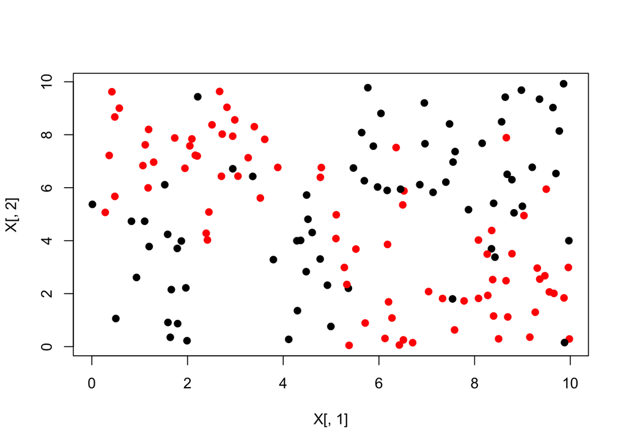

```r
plot(X[, 1], X[, 2], col=1+Y, pch=19)
```

QUESTIONS:

1. Could you classify these points accurately using only one stump?
2. If you were using a decision tree, to what depth should you build it to classify these points fairly accurately?

ANSWERS:

1. No, since the stump has only one split, and these data are not well split into just two regions.
2. The data were generated with two classification rules, plus some noise. Therefore we may be about satisfied to use just two stumps because we get a majority of the points separated, but there will definitely be some outliers.

## Boost it!

This function does boosting. It takes $X$ and $Y$, and a number of iterations (how many steps to boost?), and produces stump predictors on each step, updating the weights each time according to the boosting rules.

```r
boosted_classifiers <- function(X, Y, iterations=100) {
  N <- nrow(X)
  weights <- rep(1/N, N)

  classifiers <- list()
  alphas <- numeric(0)

  for (it in 1:iterations) {
    classifier <- stump_predictor(X, Y, weights)

    correct <- classifier(X) == Y
    err <- sum(weights * ifelse(correct, 0, 1)) # this is positive or zero

    if (err >= 0.5) {
      ## Failed in producing better-than-chance weighted error.
      ## Stop the boosting.
      break
    }

    alphas <- c(alphas, log((1 - err) / err)/ 2) # if 1 - err is greater than err, log is positive

    weights <- weights * exp(alphas[it] * ifelse(correct, -1, 1))
    weights <- weights / sum(weights)

    classifiers <- c(classifiers, classifier)
  }

  return(list(classifiers=classifiers, alpha=alphas))
}
```

QUESTIONS:

1. Examine the weighting method. If a point is correctly classified on step 5, what will happen to its weight on step 6? What about a weight incorrectly classified on step 5?
2. Why should we stop when the error is greater than 0.5? What’s wrong with including such a classifier?

ANSWERS:

1. We change the weight of the point such that if it’s classified correctly, it is multiplied by some factor less than one. Otherwise it is multiplied by some factor greater than one. This means we are downweighting the correctly classified points and upweighting the incorrectly classified point.
2. This would mean the error is worse than chance so this type of classifier is not going to be useful to improve the classification.

Next, we write a function that takes the output of `boosted_classifiers` and uses those classifiers to make predictions. It takes an optional argument $M$: if we did 20 boosting steps, but set $M = 10$, it will only use the first ten predictors.

```r
boosted_predictions <- function(boosted, new_X, M=length(boosted$classifiers)) {
  N <- nrow(new_X)

  predictions <- matrix(NA, nrow=N, ncol=M)

  classifiers <- boosted$classifiers
  alpha <- boosted$alpha[1:M]

  for (classifier in 1:M) {
    ## We center the outputs to be between -0.5 and 0.5. That way we can scale
    ## everything by alpha and then just see if the sum is greater or less than 0.
    predictions[, classifier] <- classifiers[[classifier]](new_X) - 0.5
  }

  rows <- numeric(N)
  for (row in 1:N) {
    rows[row] <- if(sum(predictions[row, ] * alpha) >= 0) { 1 } else { 0 }
  }

  return(rows)
}
```

## Try it!

```r
boosted <- boosted_classifiers(X, Y, iterations=200)

predictions <- boosted_predictions(boosted, X)
```

Now, calculate the error rate, and compare it to the fraction of observations that are 0 or 1 as a baseline:

```r
## TODO You fill this in!
length(Y[Y==0])
```

```
## [1] 70
```

```r
length(Y[Y==1])/length(Y) #0.51
```

```
## [1] 0.5333333
```

```r
error <- 1-length(Y[Y==predictions])/length(Y)
error
```

```
## [1] 0.14
```

QUESTION: Comment on the results. How much better do you do?

## Visualizing the boost

Let’s see how the boosted model makes its predictions using individual stumps.

This function plots the predictions and correctness at multiple steps of the boosting process.

```r
suppressMessages(library(ggplot2))
library(gridExtra)

plot_predictions <- function(X, Y, boosted, steps=seq(1, length(boosted$alpha))) {

  results <- data.frame(X1=numeric(0), X2=numeric(0), Y=numeric(0), predicted=numeric(0), correct=logical(0), step=numeric(0))
  for (step in steps) {
    predictor <- boosted$classifiers[[step]]
    predictions <- predictor(X)

    results <- rbind(results,
                     data.frame(X1=X[, 1], X2=X[, 2], Y=Y, predicted=predictions,
                        correct=(predictions == Y), step=step))
  }

  ggplot(results, aes(x=X1, y=X2, color=correct, shape=factor(predicted))) +
    geom_point() + theme_bw() + facet_wrap(vars(step)) +
    labs(color="Correct?", shape="Prediction")
}
```

Examine the predictions in the first few steps:

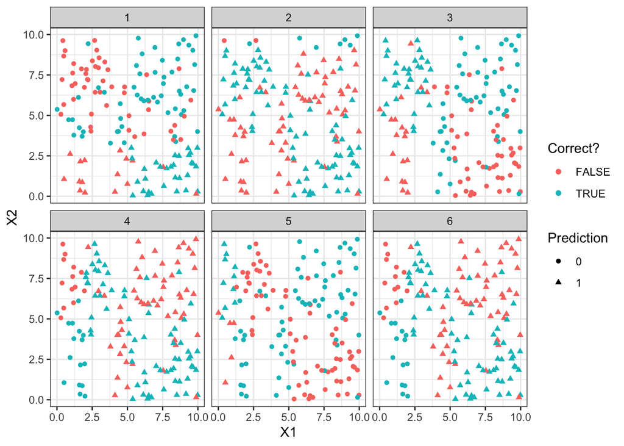

```r
plot_predictions(X, Y, boosted, 1:6)
```

## Explore the accuracy as we boost more

This function takes the output of `boosted_classifiers`, plus a dataset $X$ and $Y$, and repeatedly evaluates the accuracy for the boosted model with 1 classifier, then 2, then 3, and so on:

```r
plot_accuracy <- function(boosted, X, Y) {
  num_classifiers <- length(boosted$alpha)

  accuracies <- numeric(num_classifiers)

  for (i in 1:num_classifiers) {
    accuracies[i] <- mean(boosted_predictions(boosted, X, i) ==
                            Y)
  }

  plot(1:num_classifiers, accuracies,
       xlab="Number of boosted classifiers", ylab="Accuracy", pch=19)
}
```

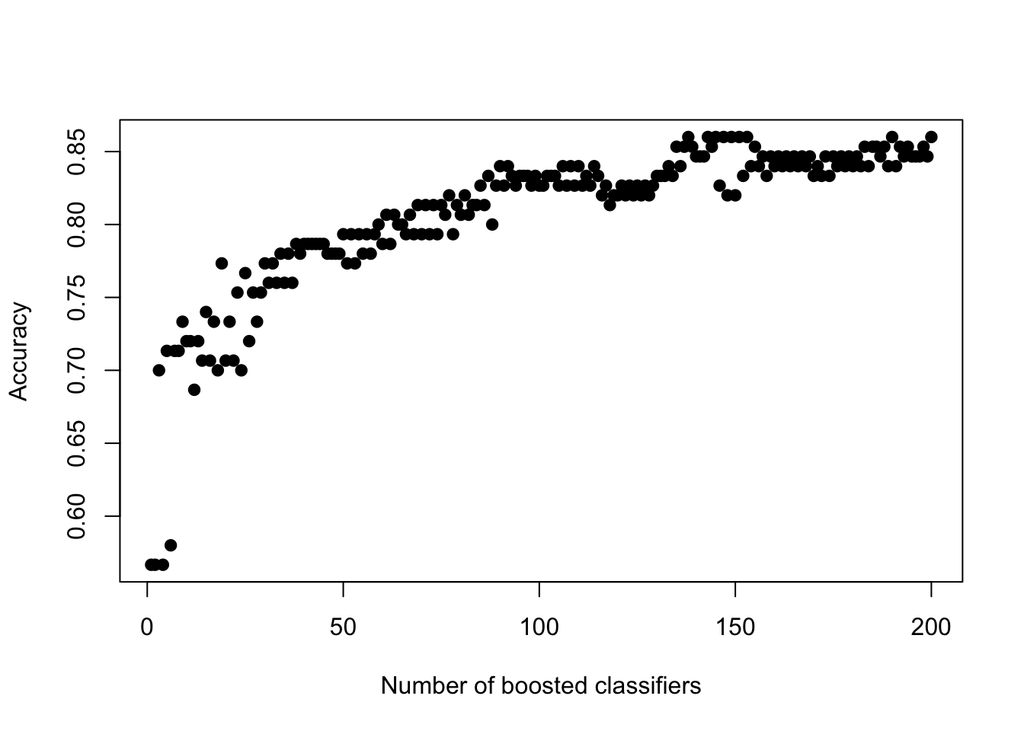

```r
plot_accuracy(boosted, X, Y)
```

QUESTIONS:

1. Above, you answered a question about the depth of a tree that’d be needed to classify this data well. How many steps did boosting take to get good accuracy? Why are the numbers so different?
2. What advantages do you see boosting as having, versus just building and pruning a decision tree?

ANSWERS:

1. We require about 50 classifiers, but we predicted we need 2. The numbers may be different because we wanted to get to 80% accuracy and there were many points which lay outside of the quadrant that we would get with just two stumps.
2. It seems that by increasing the number of classifiers, boosting will converge to the optimal solution. However if we were to prune a tree, depending on which splits we choose in which order, it may not always find this solution. As well, boosting may be quicker and easier to implement.

Use the `make_data()` function from above to make a *new* dataset of $X$ and $Y$. Then use `plot_accuracy` to show the accuracy of the boosted models to this test set:

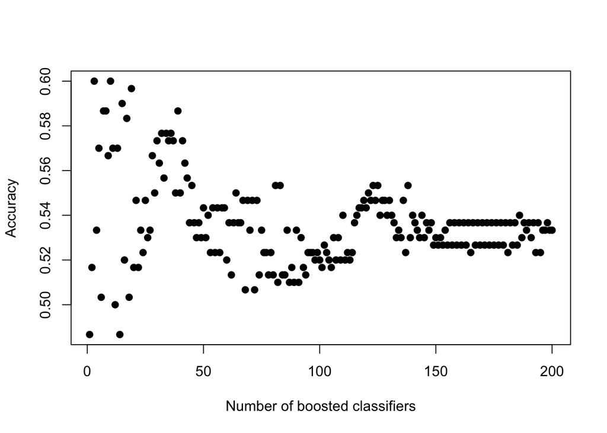

```r
## TODO You fill in!
new <- make_data(300)

new_boosted <- boosted_classifiers(new$X, new$Y, iterations=200)
plot_accuracy(boosted, new$X, new$Y)
```

QUESTION: How does it compare to the plot before? What might explain the differences?

ANSWER: The plot shows that the accuracy of the boosted classifiers is much lower and doesn’t seem to converge. This suggests that the model doesn’t generalize well, since we have overfit to the training data. With boosting, we are unable to easily capture interactions between the dimensions X1 and X2 using an average of stumps. However when we have >100 classifiers there is still a slightly better performance than by random guessing.